# Final Project

SYS 6018 - Data Mining  
Holden Bruce  
hab6xf

Some major points of feedback I received from Part 1 that I implemented in this final project submission:

- Improved Exploratory Data Analysis
  - more questions being asked of the data before diving in
  - better labels for plots
- Implementing GridSearchCV
  - From Scott: "While you don't *have* to use these capabilities [referring to GridSearchCV and KFold] for part 2 of the project, my personal feeling is that one coming out of the ISLR level (but for Python) *absolutely SHOULD* have these tools as their go to's"
  - I first implemented GridSearchCV for finding the optimal hyperparameters through the use of param_grid for both random forest and support vector machines. Then I replaced the train_test_split with KFold, since Scott argued that this method is better in every way.
- Implementing KFolds instead of train_test_split() from scikit-learn https://datascience.stackexchange.com/questions/52632/cross-validation-vs-train-validate-test https://towardsdatascience.com/complete-guide-to-pythons-cross-validation-with-examples-a9676b5cac12 https://towardsdatascience.com/train-test-split-and-cross-validation-in-python-80b61beca4b6 https://towardsdatascience.com/5-reasons-why-you-should-use-cross-validation-in-your-data-science-project-8163311a1e79#:~:text=The%20training%20set%20is%20used,do%20more%20than%20one%20split.  
  ^ these helped quite a bit as I was exploring KFolds and learning how to implement it in place of train_test_split.
- Labeling Blue Tarps as 'positive' instead of as 'negative'
  - in Part 1 I had this designation flipped which, as Scott rightly pointed out, is pretty confusing to whoever is reviewing my findings since it goes against the convention of having 1 (positive) being associated with the thing you are looking for and 0 typically representing the opposite.
- Actually considered the uncertainty of scores in the selection process.

### All the libraries and packages used in this project

```python
import numpy as np
import matplotlib.pyplot as plt
from itertools import cycle

from sklearn import svm, datasets
from sklearn.metrics import roc_curve, auc
from sklearn.model_selection import train_test_split
from sklearn.model_selection import KFold
from sklearn.preprocessing import label_binarize
from sklearn.multiclass import OneVsRestClassifier
from scipy import interp
from sklearn.metrics import roc_auc_score

import numpy as np
import pandas as pd
import seaborn as sns
import matplotlib.pyplot as plt

from sklearn import neighbors
from sklearn.metrics import confusion_matrix, classification_report,accuracy_score
from sklearn.metrics import precision_recall_fscore_support
from sklearn.neighbors import KNeighborsClassifier
from sklearn.model_selection import train_test_split


from sklearn.discriminant_analysis import LinearDiscriminantAnalysis
from sklearn.discriminant_analysis import QuadraticDiscriminantAnalysis
from sklearn.linear_model import LogisticRegression

from sklearn.ensemble import RandomForestClassifier
from sklearn.model_selection import cross_val_score
from sklearn.model_selection import RandomizedSearchCV

from sklearn.utils import resample # downsample the dataset
from sklearn import preprocessing # scale and center data
from sklearn.svm import SVC # this will make a support vector machine for classificaiton
from sklearn.metrics import plot_confusion_matrix # draws a confusion matrix
from sklearn.model_selection import GridSearchCV # this will do cross validation

import webcolors
from mpl_toolkits import mplot3d
```

Another piece of feedback I got from Scott after the submission of Part 1 was that I could improve the readability of some of the tables and graphs I had. So this next section sets the precision and general format for data output in this project. I've chosen to specify the precision of decimals returned in pandas to 3.

```python
pd.set_option('precision', 3) # number precision for pandas
pd.set_option('display.max_rows', 12)
pd.set_option('display.max_columns', 12)
pd.set_option('display.float_format', '{:20,.4f}'.format) # get rid of scientific notation
plt.style.use('seaborn') # pretty matplotlib plots
```

```python
pixels = pd.read_csv('HaitiPixels.csv', na_values=["?"])
holdout = pd.read_csv('concat_data.csv', na_values=["?"])
# see the starting.py submission for how I created the holdout dataset
```

```python
pixels.head()
```

|  | Class | Red | Green | Blue |
| --- | --- | --- | --- | --- |
| 0 | Vegetation | 64 | 67 | 50 |
| 1 | Vegetation | 64 | 67 | 50 |
| 2 | Vegetation | 64 | 66 | 49 |
| 3 | Vegetation | 75 | 82 | 53 |
| 4 | Vegetation | 74 | 82 | 54 |

```python
pixels.info()
# Class is type object
# Red, Green, Blue are all type int64
# This is expected. The Red, Green, Blue columns represent the RGB color scheme
# while the Class column represents the Classification of the object or pixel
# from the original picture that his dataset was developed from.
```

```
<class 'pandas.core.frame.DataFrame'>
RangeIndex: 63241 entries, 0 to 63240
Data columns (total 4 columns):
 #   Column  Non-Null Count  Dtype
---  ------  --------------  -----
 0   Class   63241 non-null  object
 1   Red     63241 non-null  int64
 2   Green   63241 non-null  int64
 3   Blue    63241 non-null  int64
dtypes: int64(3), object(1)
memory usage: 1.9+ MB
```

```python
pixels['Class'].unique()
```

```
array(['Vegetation', 'Soil', 'Rooftop', 'Various Non-Tarp', 'Blue Tarp'],
      dtype=object)
```

We see here that there are 5 classifications in the Class column. However, I am going to approach this as a binary classification problem instead of as a multiclass problem, so a bit lower I will map the classification 'Blue Tarp' to 1 and the other 4 classifications to 0.

```python
holdout.head()
```

|  | Red | Green | Blue | Class |
| --- | --- | --- | --- | --- |
| 0 | 104 | 89 | 63 | 0 |
| 1 | 101 | 80 | 60 | 0 |
| 2 | 103 | 87 | 69 | 0 |
| 3 | 107 | 93 | 72 | 0 |
| 4 | 109 | 99 | 68 | 0 |

```python
holdout.info()
```

```
<class 'pandas.core.frame.DataFrame'>
RangeIndex: 2008623 entries, 0 to 2008622
Data columns (total 4 columns):
 #   Column  Dtype
---  ------  -----
 0   Red     int64
 1   Green   int64
 2   Blue    int64
 3   Class   int64
dtypes: int64(4)
memory usage: 61.3 MB
```

Unlike the pixels dataset, all 4 columns in the holdout dataset are type int64. This is expected since I already mapped the data to 0 and 1 (see starting.py file). For every file that was designated as "NON" or "NOT", I created a new column "Class" and populated every row with 0. For all the other files, I created a new column "Class" and populated every row with 1.

This next function takes in a dataset and splits it into X and y, where y is the "Class" column and X are the Red, Green, Blue columns. The if-statement near the bottom of the function will not apply to the holdout dataset because I already did the 0/1 mapping in the starting.py file, but it will apply to the pixels dataset and turn the 5 different classifications seen in the "Class" column (['Vegetation', 'Soil', 'Rooftop', 'Various Non-Tarp', 'Blue Tarp']) into a list of 0's and 1's where "Blue Tarp" is mapped to 1 and the rest are mapped to 0. The reason why I have done this is that it makes it easier dealing with some of the models you will see below.

```python
def load_data(dataset):

    #set X and y and then create train and test data from the dataset
    X = dataset.drop(['Class'], axis=1) #X is columns: Red, Green, Blue

    y = dataset.Class #Y is the Class column
    # if 'Class' in dataset.columns:
    #     y = dataset.Class #Y is the Class column
    # if 'tarp' in dataset.columns:
    #     y = dataset.tarp
    #this remapping turns Blue Tarp into classification=1 while every other choice
    #is mapped to 0...thus making it a binary

    #if y is still an object containing multiple categories, map those categories to 0s and 1s
    #otherwise, don't do anything so that the X,y split from this function can be
    #used for other purposes
    if y.dtype != 'int64':
        dataset.Class = dataset.Class.astype('category')
        y = y.map({'Blue Tarp':1, 'Rooftop':0,'Soil':0,'Various Non-Tarp':0, 'Vegetation':0})

        #rewrite the Class column in pixels with the new mapped version stored in y
        pixels['Class'] = y

    return X,y
```

The pixels dataset has 63,241 observations. The holdout dataset has 2,008,623 observations. For now, we are only going to explore the pixels dataset. However, later on in this notebook I am going to call the load_data() function again, differentiating the pixels and holdout X and y values for a different purpose: to use the +2mil holdout dataset as our training data to be tested on the pixels dataset. The variables will be called X_pixels, y_pixels, X_holdout, and y_holdout.  
But for now, I will just be using the pixels dataset and will only refer to them as X and y.

```python
X,y = load_data(pixels)
```

Just making sure everything looks good:

```python
X.shape, y.shape
```

```
((63241, 3), (63241,))
```

```python
X.head()
```

|  | Red | Green | Blue |
| --- | --- | --- | --- |
| 0 | 64 | 67 | 50 |
| 1 | 64 | 67 | 50 |
| 2 | 64 | 66 | 49 |
| 3 | 75 | 82 | 53 |
| 4 | 74 | 82 | 54 |

```python
y.unique()
```

```
array([0, 1])
```

Now I'm going to use webcolors to convert RGB to hexcode, then I will use the hexcode values for each row to populate a 3D scatterplot.

```python
X_plot = X.copy()
print(X_plot)
```

```
       Red  Green  Blue
0       64     67    50
1       64     67    50
2       64     66    49
3       75     82    53
4       74     82    54
...    ...    ...   ...
63236  138    146   150
63237  134    141   152
63238  136    143   151
63239  132    139   149
63240  133    141   153

[63241 rows x 3 columns]
```

```python
# going to use webcolors to convert RGB to hexcode
# conda install -c conda-forge webcolors
# import webcolors

# the three possible classes
classes = ['Red','Green','Blue']

# loop through each row of X
for row in range(len(X_plot)):
    red = 0 #temporary assignment of red
    green = 0 #temporary assignment of green
    blue = 0 #temporary assignment of blue

    # loop through the three columns in each row
    for color in classes:
        if color == 'Red':
            red = X_plot[color][row] #assign temporary variable red to the value stored in this cell
        if color == 'Green':
            green = X_plot[color][row] #assign temporary variable green to the value stored in this cell
        if color == 'Blue':
            blue = X_plot[color][row] #assign temporary variable blue to the value stored in this cell

            # add a new column 'hex' with the hex values calculated from the temporary red, green, and blue values
            X_plot['hex'][row] = webcolors.rgb_to_hex((red,green,blue))

print(X_plot)
```

```
       Red  Green  Blue      hex
0       64     67    50  #404332
1       64     67    50  #404332
2       64     66    49  #404231
3       75     82    53  #4b5235
4       74     82    54  #4a5236
...    ...    ...   ...      ...
63236  138    146   150  #8a9296
63237  134    141   152  #868d98
63238  136    143   151  #888f97
63239  132    139   149  #848b95
63240  133    141   153  #858d99

[63241 rows x 4 columns]
```

```python
X_plot['hex']
```

```
0        #404332
1        #404332
2        #404231
3        #4b5235
4        #4a5236
          ...
63236    #8a9296
63237    #868d98
63238    #888f97
63239    #848b95
63240    #858d99
Name: hex, Length: 63241, dtype: object
```

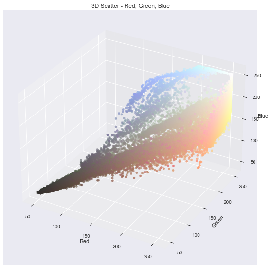

```python
%matplotlib inline
plt.rcParams["figure.figsize"] = 12.8, 9.6

ax = plt.axes(projection='3d')
ax.scatter(np.reshape(X_plot['Red'], -1), np.reshape(X_plot['Green'], -1), np.reshape(X_plot['Blue'], -1), c=X_plot['hex'])
ax.set_title('3D Scatter - Red, Green, Blue')
ax.set_xlabel('Red')
ax.set_ylabel('Green')
ax.set_zlabel('Blue')
plt.show()
```

### Splitting the data into test and train sets (KFolds)

In Part 1 of the project I used train_test_split() to split the data into training data and testing data. But for Part 2, I will use KFold to split the data.

https://medium.com/@hjhuney/implementing-a-random-forest-classification-model-in-python-583891c99652  
"Random forests tend to shine in scenarios where a model has a large number of features that individually have weak predicative power but much stronger power collectively."

Function I wrote for Part 1 using train_test_split():

```python
## Test-Train Split
# def train_test(X,y):
#     X_train, X_test, y_train, y_test = train_test_split(X, y, test_size=0.25, random_state=42) #split 75% for train and 25% test
#     # X_train #A matrix containing the predictors associated with the training data (47,430 pixels)
#     # X_test #A matrix containing the predictors associated with the test data (15,811 pixels)
#     # y_train #A vector containing the class labels for the training observations, labeled Y_train below.
#     return X_train, X_test, y_train, y_test
# X_train, X_test, y_train, y_test = train_test(X,y)
```

Now I will use KFold. Here are two of the main benefits:

1. Introducing cross-validation into the process helps reduce the need for the validation set because we are now able to train and test on the same data.
   - https://towardsdatascience.com/complete-guide-to-pythons-cross-validation-with-examples-a9676b5cac12
2. Even though sklearn's train_test_split method is using a stratified split, which means that the train and test set have the same distribution as the target variable, it’s still entirely possible to accidentally train on a subset that doesn’t reflect the whole dataset. KFolds mitigates that threat, reducing the potential bias.

KFold function for Part 2 that replaces the need for using train_test_split:

```python
def kfold_train_test_split(X,y):

    #n_splits=10 means that the KFold will shift the test set 10 times
    #shuffle is False by default but if shuffle=True then splitting will be random
    kf = KFold(n_splits=10, shuffle=True, random_state=313)
    kf.get_n_splits(X)
    # print(kf)

    # for train_index, test_index in kf.split(X,y):
    #      # print("TRAIN:", np.take(X,train_index), "TEST:", test_index)
    #      X_train, X_test = X[train_index], X[test_index]
    #      y_train, y_test = y[train_index], y[test_index]

         # getting this error:
         # KeyError: "None of [Int64Index([    0,     1,     2,     3,     5,     6,     7,     8,     9,\n               10,\n            ...\n            63226, 63227, 63229, 63230, 63233, 63234, 63236, 63237, 63238,\n            63239],\n           dtype='int64', length=47430)] are in the [columns]"
         # realize that I cannot use a pandas dataframe since KFold uses numpy arrays
         # so need to convert the pandas dataframes i'm using into numpy arrays
         # in order for this to work

    # convert pandas dataframe into numpy array:
    X_np = X.to_numpy()
    y_np = y.to_numpy()

    # split the new X_np and y_np into train and test
    for train_index, test_index in kf.split(X_np):
        # print("TRAIN:", np.take(X_np,train_index), "TEST:", np.take(X_np, test_index))
        X_train, X_test = X_np[train_index], X_np[test_index]
        y_train, y_test = y_np[train_index], y_np[test_index]

        # now save the variables back as a pandas dataframe
        # X_train, X_test = pd.DataFrame(data=X_np[train_index], columns=['Red','Green','Blue']), pd.DataFrame(data=X_np[test_index], columns=['Red','Green','Blue'])
        # y_train, y_test = pd.DataFrame(data=y_np[train_index], columns=['Blue Tarp']), pd.DataFrame(data=y_np[test_index], columns=['Blue Tarp'])


    return X_train, X_test, y_train, y_test

X_train, X_test, y_train, y_test = kfold_train_test_split(X,y)
```

### Data Leakage: Scaling our data

Now that we have X and y split into train and test sets, we can use those splits to scale our data to prevent data leakage.

```python
def scale_X_data(X_train_foo, X_test_foo):
    #then we will scale the data using StandardScaler
    scaler = preprocessing.StandardScaler().fit(X_train_foo)
    X_train_foo_scaled = scaler.transform(X_train_foo)
    X_test_foo_scaled = scaler.transform(X_test_foo)

    return X_train_foo_scaled, X_test_foo_scaled

X_train_scaled, X_test_scaled = scale_X_data(X_train, X_test)
```

## Methods from Part 1

This next section is going to be applying the scaled data to the methods from Part 1 of the project.

#### Finding the optimal value of K for KNN

```python
#KNN-specific
def optimal_K(X_train_knn, X_test_knn, y_train_knn, y_test_knn):
    ### Testing for best/optimal K value
    # def find_optimal_k
    accuracy_rate_dict = {}
    for i in range(1,40):
        knn = neighbors.KNeighborsClassifier(n_neighbors=i)
        knn_pred = knn.fit(X_train_knn, y_train_knn).predict(X_test_knn)
        accuracy_rate_dict[accuracy_score(y_test_knn, knn_pred)] = i
    max(accuracy_rate_dict)
    best_k = accuracy_rate_dict[max(accuracy_rate_dict)] #20
    print('KNN performs best when the classifier k={}'.format(best_k))

    K = best_k #A value for K, the number of nearest neighbors to be used by the classifier.
    return K
```

#### KNN

This knn() function works rather differently from the other model-fitting functions that we have encountered thus far. Rather than a two-step approach in which we first fit the model and then we use the model to make predictions, knn() forms predictions using a single command. The function requires four inputs: X_train, X_test, y_train, and y_test.

```python
def knn(X_train_knn, X_test_knn, y_train_knn, y_test_knn):

    K = optimal_K(X_train_knn, X_test_knn, y_train_knn, y_test_knn)

    """Now the neighbors.KNeighborsClassifier() function can be used to predict the
    classification of Blue Tarp, Rooftop, Soil, Various Non-Tarp, or Vegetation"""
    # fit a model
    knn = neighbors.KNeighborsClassifier(n_neighbors = K)

    #predict classification
    knn_pred = knn.fit(X_train_knn, y_train_knn).predict(X_test_knn) #fit the model and predict

    # predict probabilities
    knn_probs = knn.fit(X_train_knn, y_train_knn).predict_proba(X_test_knn) #fit the model and predict

    # keep probabilities for the positive outcome only
    knn_probs = knn_probs[:, 1]

    return knn_pred, knn_probs
```

```python
#unscaled data
knn_pred, knn_probs = knn(X_train, X_test, y_train, y_test)
```

```
KNN performs best when the classifier k=6
```

```python
#scaled data
knn_pred_scaled, knn_probs_scaled = knn(X_train_scaled, X_test_scaled, y_train, y_test)
```

```
KNN performs best when the classifier k=8
```

Our knn() and optimal_k() functions report that the optimal classifier is k=6 with unscaled data and k=8 when using the scaled data.

#### LDA -- Linear Discriminant Analysis

```python
def lda(X_train_lda, X_test_lda, y_train_lda, y_test_lda):
    # fit a model
    lda = LinearDiscriminantAnalysis()

    #predict classification
    lda_pred = lda.fit(X_train_lda, y_train_lda).predict(X_test_lda)

    # predict probabilities
    lda_probs = lda.fit(X_train_lda, y_train_lda).predict_proba(X_test_lda)

    # keep probabilities for the positive outcome only
    lda_probs = lda_probs[:, 1]

    return lda_pred, lda_probs

lda_pred_scaled, lda_probs_scaled = lda(X_train_scaled, X_test_scaled, y_train, y_test)
```

#### QDA -- Quadratic Discriminant Analysis

```python
def qda(X_train_qda, X_test_qda, y_train_qda, y_test_qda):
    # fit a model
    qda = QuadraticDiscriminantAnalysis()

    #predict classification
    qda_pred = qda.fit(X_train_qda, y_train_qda).predict(X_test_qda)

    # predict probabilities
    qda_probs = qda.fit(X_train_qda, y_train_qda).predict_proba(X_test_qda)

    # keep probabilities for the positive outcome only
    qda_probs = qda_probs[:, 1]

    return qda_pred, qda_probs
```

```python
#unscaled data
qda_pred, qda_probs = qda(X_train, X_test, y_train, y_test)
```

```python
#scaled data
qda_pred_scaled, qda_probs_scaled = qda(X_train_scaled, X_test_scaled, y_train, y_test)
```

#### Logistic Regression

```python
def logistic_regression(X_train_logreg, X_test_logreg, y_train_logreg, y_test_logreg):
    # fit a model
    model = LogisticRegression(solver='lbfgs')

    #predict classification
    logreg_pred = model.fit(X_train_logreg, y_train_logreg).predict(X_test_logreg)

    # predict probabilities
    logreg_probs = model.fit(X_train_logreg, y_train_logreg).predict_proba(X_test_logreg)

    # keep probabilities for the positive outcome only
    logreg_probs = logreg_probs[:, 1]

    return logreg_pred, logreg_probs
```

```python
#unscaled data
logreg_pred, logreg_probs = logistic_regression(X_train, X_test, y_train, y_test)
```

```python
#scaled data
logreg_pred_scaled, logreg_probs_scaled = logistic_regression(X_train_scaled, X_test_scaled, y_train, y_test)
```

# Part 2

Now we will build out the Random Forest and Support Vector Machine models.

A note on decision trees: individual decision trees are fragile in the sense that they are only as good as the data on which they are trained. If the underlying data changes, then so will the decision tree's prediction.

Random Forests reduce this variance by creating decision trees for many subsets of the data and then taking the average of all those decision trees. In a typical Random Forest, a random subset of the features are chosen for each decision tree. In a bagging model, all of the features are chosen for each decision tree.

#### Bagging

```python
def bagging(X_train_bag, X_test_bag, y_train_bag, y_test_bag):
    # fit a model
    rfc = RandomForestClassifier(max_features=X_train.shape[1],random_state=313)

    #predict classification
    bagging_pred = rfc.fit(X_train_bag, y_train_bag).predict(X_test_bag)

    # predict probabilities
    bagging_probs = rfc.fit(X_train_bag, y_train_bag).predict_proba(X_test_bag)

    # keep probabilities for the positive outcome only
    bagging_probs = bagging_probs[:, 1]

    return bagging_pred, bagging_probs, rfc
```

```python
#unscaled data
bagging_pred, bagging_probs, rfc = bagging(X_train, X_test, y_train, y_test)
```

```python
#scaled data
bagging_pred_scaled, bagging_probs_scaled, rfc_scaled = bagging(X_train_scaled, X_test_scaled, y_train, y_test)
```

Now let's evaluate how the model performed:

```python
# Evaluating Performance:
def eval_perform_rf(rfc, X_whole_dataset, y_whole_dataset, y_test_rf, bagging_pred):
    # calculate the cross_val_score for the bagging model, using rfc from the bagging() function
    bagging_cv_score = cross_val_score(rfc, X_whole_dataset, y_whole_dataset, cv=10, scoring='roc_auc', n_jobs=-1)
    # using n_jobs=-1 to speed up the run time

    for i in range(len(bagging_cv_score)):
        print('CV={}: {}'.format(i+1,bagging_cv_score[i]))
    print('\n')

    print("=== Confusion Matrix ===")
    print(confusion_matrix(y_test_rf, bagging_pred))
    print('\n')

    print("=== Classification Report ===")
    print(classification_report(y_test_rf, bagging_pred))
    print('\n')

    print("=== All AUC Scores ===")
    print(bagging_cv_score)
    print('\n')

    print("=== Mean AUC Score ===")
    print("Mean AUC Score - Random Forest: ", bagging_cv_score.mean())
```

```python
#unscaled data
eval_perform_rf(rfc, X, y, y_test, bagging_pred)
```

```
CV=1: 1.0
CV=2: 0.9999482470298647
CV=3: 0.9975247524752475
CV=4: 1.0
CV=5: 1.0
CV=6: 1.0
CV=7: 0.9868721313490382
CV=8: 0.9940132325875515
CV=9: 0.9081534378527693
CV=10: 0.9993541574954349


=== Confusion Matrix ===
[[6123    4]
 [   7  190]]


=== Classification Report ===
              precision    recall  f1-score   support

           0       1.00      1.00      1.00      6127
           1       0.98      0.96      0.97       197

    accuracy                           1.00      6324
   macro avg       0.99      0.98      0.99      6324
weighted avg       1.00      1.00      1.00      6324



=== All AUC Scores ===
[1.         0.99994825 0.99752475 1.         1.         1.
 0.98687213 0.99401323 0.90815344 0.99935416]


=== Mean AUC Score ===
Mean AUC Score - Random Forest:  0.9885865958789907
```

```python
#scaled data
eval_perform_rf(rfc_scaled, X, y, y_test, bagging_pred_scaled)
```

```
CV=1: 1.0
CV=2: 0.9999482470298647
CV=3: 0.9975247524752475
CV=4: 1.0
CV=5: 1.0
CV=6: 1.0
CV=7: 0.9868721313490382
CV=8: 0.9940132325875515
CV=9: 0.9081534378527693
CV=10: 0.9993541574954349


=== Confusion Matrix ===
[[6123    4]
 [   7  190]]


=== Classification Report ===
              precision    recall  f1-score   support

           0       1.00      1.00      1.00      6127
           1       0.98      0.96      0.97       197

    accuracy                           1.00      6324
   macro avg       0.99      0.98      0.99      6324
weighted avg       1.00      1.00      1.00      6324



=== All AUC Scores ===
[1.         0.99994825 0.99752475 1.         1.         1.
 0.98687213 0.99401323 0.90815344 0.99935416]


=== Mean AUC Score ===
Mean AUC Score - Random Forest:  0.9885865958789907
```

This is pretty great. 98.86% accuracy for the AUC score.

- The confusion matrix is useful for giving you false positives and false negatives.
- The classification report tells you the accuracy of your model.
- The ROC curve plots out the true positive rate versus the false positive rate at various thresholds.
- The roc_auc scoring used in the cross-validation model shows the area under the ROC curve.

We’ll evaluate our model’s score based on the roc_auc score (stored in bagging_cv_score.mean() and returned as "Mean AUC Score - Random Forest"), which is 0.9886 in this model.

The next thing we should do is tune our hyperparameters to see if we can improve the performance of the model. https://medium.com/@hjhuney/implementing-a-random-forest-classification-model-in-python-583891c99652 https://towardsdatascience.com/hyperparameter-tuning-the-random-forest-in-python-using-scikit-learn-28d2aa77dd74

#### Tuning Hyperparameters

William Koehrsen’s article, “Hyperparameter Tuning the Random Forest in Python”, recommends using a full grid of hyperparameters. I actually attempted to do something similar to what he laid out in his article (see final.py for my attempt) but this took way too much time, so I ended up focusing on 3 hyperparameters.

Initially I took the lead of Jason Brownlee (Medium article above) and used n_estimators, max_features, and max_depth, but I end up revising that later on in the SVM section when I'm using the entire holdout dataset. I'll provide more explanation later on as to why I valued some hyperparameters over others.

```python
# Tuning Hyperparameters for the Random Forest model

def rf_tune_hyperparameters(rfc, X_train_rf_tune, y_train_rf_tune):
    #n_estimators determines the number of trees in the random forest
    #take 11 values of n_estimators starting from 100 and ending with 2000, equally spaced

    # n_estimators = [int(x) for x in np.linspace(start = 100, stop = 2000, num = 11)] #default is 100
    n_estimators = [10, 50, 100, 500, 1000]

    # number of features at every split
    max_features = ['auto', 'sqrt','log2', np.random.randint(1,4)] #default is auto in sklearn

    # max_depth determines the maximum depth of the tree
    #take 11 values of max_depth starting from 100 and ending with 500, equally spaced
    max_depth = [int(x) for x in np.linspace(100, 500, num = 11)]
    # max_depth = [2,3,4,5,6,7,8,9, 10, None] #None is the default for max_depth in sklearn
    # max_depth = [2,3,4]

    # criterion = ['gini','entropy']

    # create grid of these parameters that will be passed into the searchCV function
    param_grid = {
     'n_estimators': n_estimators,
     'max_features': max_features,
     'max_depth': max_depth
     }

    # GridSearchCV of the parameters
    rfc_gridsearch = GridSearchCV(
        rfc,
        param_grid,
        # verbose=2,
        n_jobs=-1
        )

    #I was getting some errors using pandas dataframes with this model fit
    #so changing to numpy array
    #rfc_gridsearch.fit(X_train_rf.to_numpy(), y_train_rf.to_numpy())
    rfc_gridsearch.fit(X_train_rf_tune, y_train_rf_tune)
    # this is a pretty data intensive model fit which is why i have set n_jobs to -1
    #in the RandomizedSearchCV(), which means that all of my processors are being
    #used in parallel to run this fit

    # print the results:
    # print(rfc_random.best_params_)

    #now store the optimal parameters and then return them for use in other functions
    optimal_n_estimators = rfc_gridsearch.best_params_['n_estimators']
    optimal_max_features = rfc_gridsearch.best_params_['max_features']
    optimal_max_depth = rfc_gridsearch.best_params_['max_depth']
    # optimal_criterion = rfc_gridsearch.best_params_['criterion']

    print("=== Optimal n_estimators ===")
    print(optimal_n_estimators)
    print('\n')

    print("=== Optimal max_features ===")
    print(optimal_max_features)
    print('\n')

    print("=== Optimal max_depth ===")
    print(optimal_max_depth)
    print('\n')

    return rfc_gridsearch, optimal_n_estimators, optimal_max_features, optimal_max_depth
```

```python
# scaled data
# comment this next line out if you don't want to wait for the whole thing to run
rfc_gridsearch_scaled, optimal_n_estimators_scaled, optimal_max_features_scaled, optimal_max_depth_scaled = rf_tune_hyperparameters(rfc_scaled, X_train_scaled, y_train)
```

```
=== Optimal n_estimators ===
500


=== Optimal max_features ===
auto


=== Optimal max_depth ===
100
```

Now we can plug these back values into the model to see if it improves our model's performance.

```python
def rf_optimal(optimal_n, optimal_feat, optimal_depth):
    rfc_optimal = RandomForestClassifier(n_estimators=optimal_n_estimators, max_depth=optimal_max_depth, max_features=optimal_max_features, random_state=313, n_jobs=-1)
    rfc_optimal.fit(X_train,y_train)
    rfc_optimal_predict = rfc_optimal.predict(X_test)
    rfc_optimal_cv_score = cross_val_score(rfc_optimal, X, y, cv=10, scoring='roc_auc', n_jobs=-1)
    for i in range(len(rfc_optimal_cv_score)):
        print('CV={}: {}'.format(i+1,rfc_optimal_cv_score[i]))
    print('\n')

    print("=== Confusion Matrix ===")
    print(confusion_matrix(y_test, rfc_optimal_predict))
    print('\n')
    # === Confusion Matrix ===
    # [[15289    18]
    #  [   25   479]]

    print("=== Classification Report ===")
    print(classification_report(y_test, rfc_optimal_predict))
    print('\n')

    print("=== All AUC Scores ===")
    print(rfc_optimal_cv_score)
    print('\n')

    print("=== Mean AUC Score ===")
    print("Mean AUC Score - Random Forest: ", rfc_optimal_cv_score.mean())

    return rfc_optimal_cv_score
```

```python
#unscaled data
rf_opimal_cv_score = rf_optimal(optimal_n_estimators, optimal_max_features, optimal_max_depth)
```

```
CV=1: 1.0
CV=2: 0.9865676783294142
CV=3: 0.9998859817376706
CV=4: 1.0
CV=5: 1.0
CV=6: 1.0
CV=7: 0.9988040212057796
CV=8: 0.998960493076423
CV=9: 0.9393924201306115
CV=10: 0.9994366482826222


=== Confusion Matrix ===
[[6125    2]
 [   7  190]]


=== Classification Report ===
              precision    recall  f1-score   support

           0       1.00      1.00      1.00      6127
           1       0.99      0.96      0.98       197

    accuracy                           1.00      6324
   macro avg       0.99      0.98      0.99      6324
weighted avg       1.00      1.00      1.00      6324



=== All AUC Scores ===
[1.         0.98656768 0.99988598 1.         1.         1.
 0.99880402 0.99896049 0.93939242 0.99943665]


=== Mean AUC Score ===
Mean AUC Score - Random Forest:  0.9923047242762519
```

```python
#scaled data
rf_opimal_cv_score_scaled = rf_optimal(optimal_n_estimators_scaled, optimal_max_features_scaled, optimal_max_depth_scaled)
```

```
CV=1: 1.0
CV=2: 0.9865676783294142
CV=3: 0.9998859817376706
CV=4: 1.0
CV=5: 1.0
CV=6: 1.0
CV=7: 0.9988040212057796
CV=8: 0.998960493076423
CV=9: 0.9393924201306115
CV=10: 0.9994366482826222


=== Confusion Matrix ===
[[6125    2]
 [   7  190]]


=== Classification Report ===
              precision    recall  f1-score   support

           0       1.00      1.00      1.00      6127
           1       0.99      0.96      0.98       197

    accuracy                           1.00      6324
   macro avg       0.99      0.98      0.99      6324
weighted avg       1.00      1.00      1.00      6324



=== All AUC Scores ===
[1.         0.98656768 0.99988598 1.         1.         1.
 0.99880402 0.99896049 0.93939242 0.99943665]


=== Mean AUC Score ===
Mean AUC Score - Random Forest:  0.9923047242762519
```

This also performs incredibly well: 99.23% accuracy - AUC score. This is slightly higher than bagging but the differences seen in this confusion matrix can easily be explained by variance. There is inherent uncertainty when selecting optimal parameters for our models. This is undoubetably a great fit but the differences between this "optimal" model and the bagging model are too small to confidently say which is better.

# Support Vector Machines

Now we can create the SVM model for filling out the table

```python
### SVM

def svm(X_train_svm, X_test_svm, y_train_svm, y_test_svm):
    # fit a model
    clf_svm = SVC(random_state=313, probability=True)
    clf_svm.fit(X_train_svm, y_train_svm)

    #predict classification
    clf_svm_pred = clf_svm.fit(X_train_svm, y_train_svm).predict(X_test_svm)

    # predict probabilities
    clf_svm_probs = clf_svm.fit(X_train_svm, y_train_svm).predict_proba(X_test_svm)
    #AttributeError: predict_proba is not available when  probability=False

    # keep probabilities for the positive outcome only
    clf_svm_probs = clf_svm_probs[:, 1]

    return clf_svm_pred, clf_svm_probs, clf_svm
```

```python
clf_svm_pred, clf_svm_probs, clf_svm = svm(X_train_scaled, X_test_scaled, y_train, y_test)
```

## Downsampling

The 63,241 observations in the pixel data will take a long time for the support vector machine to run, so downsampling will make this process quicker. Support Vector Machines are great with small datasets, but they aren't so great with large ones. The pixels dataset is large enough to take a long time to optimize with a typical cross validation approach, so taking a subset of this dataset and feeding it to the SVM model will give us a good idea of how the model behaves with our data, without needing to run through every observation.

For this project I downsample both categories, Blue Tarp and Non Blue Tarp, to 2,022 each. There are only 2,022 observations where y = Blue Tarp, so I wanted to include as many as possible to make sure the model is not suffering from this reduction in training size.

```python
def downsample_data(num_samples):
    #To ensure that i actually get 2022 samples for each category, I'll start by
    #splitting the data into two dataframes, one for Class=1 (blue tarp) and one
    #for Class=0 (not blue tarp)
    pixels_blue_tarp = pixels[y==1] #pixels[pixels['Class']==1]
    pixels_not_blue_tarp = pixels[y==0] # pixels[pixels['Class']==0]

    #let's see how this breaks down
    pixels_blue_tarp.shape #(2022, 4) ... 2022 observations
    pixels_not_blue_tarp.shape #(61219, 4) ... 61219 observations
    sum(y)/len(y) #0.03197292895431761
    #This is definitely an unbalanced dataset where there are way more examples of non-
    #blue tarp observations than there are blue tarp observations (this is expected)

    #now downsample the pixels_blue_tarp dataframe
    pixels_blue_tarp_downsampled = resample(pixels_blue_tarp,
                                            replace=False,
                                            n_samples=num_samples, #pass in num_samples
                                            random_state=313)

    #now downsample the pixels_not_blue_tarp dataframe
    pixels_not_blue_tarp_downsampled = resample(pixels_not_blue_tarp,
                                            replace=False,
                                            n_samples=num_samples, #pass in num_samples
                                            random_state=313)

    #now merge the two downsampled dataframes back into a single dataframe
    pixels_downsampled = pd.concat([pixels_blue_tarp_downsampled, pixels_not_blue_tarp_downsampled])
    #then print out the total number of samples (should be 2000 or 2*num_samples) to make sure i did this correctly
    len(pixels_downsampled) #4044

    return pixels_downsampled

pixels_downsampled = downsample_data(num_samples=2022)
```

```python
pixels_downsampled.head()
```

|  | Class | Red | Green | Blue |
| --- | --- | --- | --- | --- |
| 63068 | 1 | 125 | 116 | 115 |
| 61804 | 1 | 195 | 224 | 255 |
| 62869 | 1 | 173 | 195 | 206 |
| 61303 | 1 | 171 | 193 | 225 |
| 62225 | 1 | 144 | 163 | 216 |

```python
pixels_downsampled.shape
```

```
(4044, 4)
```

### Building the SVM

Now that we have formatted our downsampled data, we can start building the support vector machine. First, we split the data into two parts:

1. the column of data we will use to make classifications
2. the column of data that we want to predict

```python
#split this data using the load_data() from above and pass it the downsampled data
X_downsampled, y_downsampled = load_data(pixels_downsampled)
```

```python
X_downsampled, y_downsampled
```

```
(       Red  Green  Blue
 63068  125    116   115
 61804  195    224   255
 62869  173    195   206
 61303  171    193   225
 62225  144    163   216
 ...    ...    ...   ...
 27592  255    252   187
 27634  227    165   150
 23947   90     84    64
 57879  168    143   108
 27032  255    230   173

 [4044 rows x 3 columns],
 63068    1
 61804    1
 62869    1
 61303    1
 62225    1
         ..
 27592    0
 27634    0
 23947    0
 57879    0
 27032    0
 Name: Class, Length: 4044, dtype: int64)
```

Nothing to one hot encode in X. Everything looks good.

But the radial basis function that we use with our support vector machine assumes that the data we feed it are centered and scaled, so we need to make sure that each column should have a mean value=0 and a standard deviation=1 for both the training and testing dataset.

We’ll use the kfold_train_test_split() function we wrote earlier to split the data into training data and testing data.

```python
X_train_downsampled, X_test_downsampled, y_train_downsampled, y_test_downsampled = kfold_train_test_split(X_downsampled, y_downsampled)
```

Then we will scale the data using the scale_X_data() from before.

```python
X_train_downsampled_scaled, X_test_downsampled_scaled = scale_X_data(X_train_downsampled, X_test_downsampled)
```

```python
X_train_downsampled_scaled, X_test_downsampled_scaled
```

[output not shown]

```python
# This function builds the SVM model and can take in either downsampled data or otherwise
# but because of SVM's structure, it expects scaled data
def build_svm(X_train_foo_scaled, X_test_foo_scaled, y_train_foo, y_test_foo, clf_svm = SVC(random_state=313)):
    # Now that we have our data split into test and train we can build our preliminary
    # support vector machine

    # clf_svm = SVC(random_state=313)
    clf_svm.fit(X_train_foo_scaled, y_train_foo)

    #that's it, that's our support vector machine for classification
    #now we can draw a confusion matrix and see how it performs on the test data

    plot_confusion_matrix(clf_svm,
                      X_test_foo_scaled,
                      y_test_foo,
                      values_format='d',
                      display_labels=["Not Blue Tarp", "Blue Tarp"])
```

```python
#unscaled data
build_svm(X_train_downsampled, X_test_downsampled, y_train_downsampled, y_test_downsampled)
```

```python
#scaled data
build_svm(X_train_downsampled_scaled,X_test_downsampled_scaled,y_train_downsampled, y_test_downsampled)
```

[output not shown]

This performs incredibly well, which always makes me pause and think whether I might be overfitting. Are these tests really performing so well or is this just evidence of random forest and SVMs being better solutions for this kind of classification problem than the methods used in Part 1?

I will use cross validation to optimize the parameters to see if I can improve predictions at all but honestly, these numbers are already fantastic. My next step would be to run the entire dataset (without downsampling) to see how it performs.

```python
### SVM -- now we can actually build the SVM model
# use the svm() function I defined above
clf_svm_pred_downsampled, clf_svm_probs_downsampled, clf_svm_downsampled = svm(X_train_downsampled_scaled, X_test_downsampled_scaled, y_train_downsampled, y_test_downsampled)
```

When we are optimizing a support vector machine we are attempting to find the best value for gamma and the regularization parameter C that will improve the prediction / classification accuracy of the model. Since we are looking to optimize two parameters (gamma and C) we will use GridSearchCV(), specifying several values for gamma and C and then letting the function determine the optimal combination (that's the great thing about using GridSerachCV() for problems like this: it tests all possible combinations of parameters for us and all we have to do is plug in some options).

The default values for the SVC parameters in sklearn.svm are:

- C=1.0
- kernel='rbf
- degree=3
- gamma='scale' (which is 1/(n_features*X.var()) while 'auto' uses 1/n_features

GridSearchSV in sklearn.model_selection has a parameter called param_grid where you can pass in a dictionary of parameters. I will pass in all of the default SVC parameters and then some extra parameters so that the GridSearchCV() can find the optimal combination from many options.

My assumption is that 'rbf' will work the best for the pixel data, so I might not need to have all these options for kernel, but I am including 'linear','poly', and 'sigmoid' anyway.

```python
def optimizing_svm():
    param_grid = [
      {'C': np.arange(0.001,5.001,.1),
       'degree':[1,2,3,4],
       'gamma': ['scale', 'auto', 1, 0.1, 0.01, 0.001, 0.0001],
       'kernel': ['rbf','linear','poly','sigmoid']},
    ]

    optimal_params = GridSearchCV(
        SVC(),
        param_grid,
        cv=5,
        scoring='accuracy',
        n_jobs=-1)

    return optimal_params
```

```python
optimal_params = optimizing_svm()
print(optimal_params)
```

Now that we have the optimal parameters for the SVM model, we need to fit the model with the optimal parameter grid. This takes a little while but here we start searching through for the best options...

```python
optimal_params.fit(X_train_downsampled_scaled, y_train_downsampled)
```

```
GridSearchCV(cv=5, estimator=SVC(), n_jobs=-1,
             param_grid=[{'C': array([1.000e-03, 1.010e-01, 2.010e-01, 3.010e-01, 4.010e-01, 5.010e-01,
       6.010e-01, 7.010e-01, 8.010e-01, 9.010e-01, 1.001e+00, 1.101e+00,
       1.201e+00, 1.301e+00, 1.401e+00, 1.501e+00, 1.601e+00, 1.701e+00,
       1.801e+00, 1.901e+00, 2.001e+00, 2.101e+00, 2.201e+00, 2.301e+00,
       2.401e+00, 2.501e+00, 2.601e+00, 2.701e+00, 2.801e+00, 2.901e+00,
       3.001e+00, 3.101e+00, 3.201e+00, 3.301e+00, 3.401e+00, 3.501e+00,
       3.601e+00, 3.701e+00, 3.801e+00, 3.901e+00, 4.001e+00, 4.101e+00,
       4.201e+00, 4.301e+00, 4.401e+00, 4.501e+00, 4.601e+00, 4.701e+00,
       4.801e+00, 4.901e+00]),
                          'degree': [1, 2, 3, 4],
                          'gamma': ['scale', 'auto', 1, 0.1, 0.01, 0.001,
                                    0.0001],
                          'kernel': ['rbf', 'linear', 'poly', 'sigmoid']}],
             scoring='accuracy')
```

```python
# Save the optimal parameters down in their own varaibles
best_C = optimal_params.best_params_['C']
best_degree = optimal_params.best_params_['degree']
best_gamma = optimal_params.best_params_['gamma']
best_kernel = optimal_params.best_params_['kernel']

# Then print out the optimal parameters for the model
print('''The best cost for clf_svm is: {}
the best degree for clf_svm is: {}
the best gamma for clf_svm is: {}
the best kernel for clf_svm is: '{}'
      '''.format(
      best_C,
      best_degree,
      best_gamma,
      best_kernel
))
```

```
The best cost for clf_svm is: 3.801
the best degree for clf_svm is: 1
the best gamma for clf_svm is: 1
the best kernel for clf_svm is: 'rbf'
```

As expected, the best kernel for the SVM model is 'rbf'.

Now we can use these optimal parameters to fit a new model:

```python
clf_svm_optimal = SVC(random_state=313, C=best_C, degree=best_degree, gamma=best_gamma, kernel=best_kernel)

build_svm(X_train_downsampled_scaled, X_test_downsampled_scaled, y_train_downsampled, y_test_downsampled, clf_svm = clf_svm_optimal)
```

[output not shown]

# Completing Table 2

#### Accuracy

```python
def accuracy(y_test, pred, method):
    accuracy = accuracy_score(y_test, pred)
    print('{} Accuracy: {}'.format(method,str(accuracy)))
    print('{} Test Error: {}'.format(method, str(1 - accuracy )))
    """that's actually not very helpful because this is scoring across classes, which
    isn't giving us a good view of the accuracy of the model...use this instead:"""

    return accuracy
    # ^^ there is a severe imbalance
    #https://machinelearningmastery.com/threshold-moving-for-imbalanced-classification/
    #need to move threshold to accommodate this imbalance
    #"It has been stated that trying other methods, such as sampling, without trying by simply setting the threshold may be misleading. The threshold-moving method uses the original training set to train [a model] and then moves the decision threshold such that the minority class examples are easier to be predicted correctly."
    #Pages 72, Imbalanced Learning: Foundations, Algorithms, and Applications, 2013.

knn_accuracy = accuracy(y_test,knn_pred,'KNN')
lda_accuracy = accuracy(y_test,lda_pred,'LDA')
qda_accuracy = accuracy(y_test,qda_pred,'QDA')
logreg_accuracy = accuracy(y_test,logreg_pred,'Logistic Regression')
bagging_accuracy = accuracy(y_test, bagging_pred,'Bagging')
svm_accuracy = accuracy(y_test_downsampled, clf_svm_pred, 'SVM')
```

```
KNN Accuracy: 0.9987349778621126
KNN Test Error: 0.0012650221378873727
LDA Accuracy: 0.9830803289057558
LDA Test Error: 0.016919671094244193
QDA Accuracy: 0.9955724225173941
QDA Test Error: 0.0044275774826059155
Logistic Regression Accuracy: 0.9966793168880456
Logistic Regression Test Error: 0.0033206831119544367
Bagging Accuracy: 0.9982605945604048
Bagging Test Error: 0.0017394054395951652
SVM Accuracy: 0.9876237623762376
SVM Test Error: 0.012376237623762387
```

#### AUC

We can then use the roc_auc_score() function to calculate the true-positive rate and false-positive rate for the predictions using a set of thresholds that can then be used to create a ROC Curve plot.

```python
def calculate_AUC(y_test, prob):
    # calculate scores
    auc = roc_auc_score(y_test, prob)
    return auc

auc_KNN = calculate_AUC(y_test, knn_pred)
print('auc_KNN:', auc_KNN)
auc_LDA = calculate_AUC(y_test, lda_pred)
print('auc_QDA:',auc_LDA)
auc_QDA = calculate_AUC(y_test, qda_pred)
print('auc_QDA:', auc_QDA)
auc_LogisticRegression = calculate_AUC(y_test, logreg_pred)
print('auc_LogisticRegression:',auc_LogisticRegression)
auc_Bagging = calculate_AUC(y_test, bagging_pred)
print('auc_Bagging:',auc_Bagging)
auc_SVM = calculate_AUC(y_test_downsampled, clf_svm_pred)
print('auc_SVM:',auc_SVM)
```

```
auc_KNN: 0.9870648266514446
auc_QDA: 0.8930095549448682
auc_QDA: 0.9363034053316476
auc_LogisticRegression: 0.9614392979729398
auc_Bagging: 0.9819070785132629
auc_SVM: 0.9871794871794871
```

#### Threshold for ROC

```python
def best_threshold(fpr, tpr, thresholds):
    # Youden's J-statistic for calculating optimal threshold
    # https://en.wikipedia.org/wiki/Youden%27s_J_statistic
    J = tpr - fpr

    best_index = 0
    #loop through J and set 'best_index' to whichever corresponds to the max(J)
    for index,value in enumerate(J):
        if value==max(J):
            best_index=index
            # print(best_index)

    best_thresh = thresholds[best_index]
    print('Best Threshold={:f}'.format(best_thresh))
    return best_index, best_thresh
```

#### ROC

```python
def calculate_ROC(y_test, prob, Type):
    # calculate roc curves
    fpr, tpr, thresholds = roc_curve(y_test, prob)

    # I cannot figure out why there are so fewer threshold values for KNN than for the other models...
    #print(thresholds)
    #fpr, tpr, threshold = roc_curve(y_test, knn_probs_scaled)
    #roc_auc = auc(fpr, tpr)
    #roc_auc

    best_index, best_thresh = best_threshold(fpr, tpr, thresholds)
    # plot the roc curve for the model
    plt.plot([0,1], [0,1], linestyle='--', label='No Skill')
    plt.plot(fpr, tpr, marker='.', label='{} ROC'.format(Type))
    #best threshold
    plt.scatter(fpr[best_index], tpr[best_index], marker='o', color='black', label='Optimal Threshold = {:3f}'.format(best_thresh))
    # axis labels
    plt.xlabel('False Positive Rate')
    plt.ylabel('True Positive Rate')
    plt.legend()
    # show the plot
    plt.show()
```

There's something strange going on with the knn_probs. I was having problems with my KNN graph in Part 1 also, and I still don't know what's going on.

```python
knn_probs, knn_probs_scaled, lda_probs, qda_probs, logreg_probs, bagging_probs, clf_svm_probs, y_test
```

```
(array([0., 0., 0., ..., 1., 1., 1.]),
 array([0., 0., 0., ..., 1., 1., 1.]),
 array([2.05501771e-07, 6.29110862e-08, 2.45905046e-08, ...,
        7.69431324e-01, 2.02634597e-01, 3.85522437e-01]),
 array([3.01152104e-05, 5.54408800e-05, 4.73949799e-05, ...,
        9.55472207e-01, 6.88937343e-01, 8.17629709e-01]),
 array([6.05578009e-04, 5.47287018e-05, 6.51550577e-06, ...,
        9.95684810e-01, 9.75742188e-01, 9.93962442e-01]),
 array([0.  , 0.  , 0.  , ..., 1.  , 0.99, 1.  ]),
 array([2.41113360e-04, 1.61771099e-04, 1.48139130e-04, ...,
        9.94769770e-01, 9.92174498e-01, 9.97303814e-01]),
 array([0, 0, 0, ..., 1, 1, 1]))
```

There are significantly fewer unique values in the KNN compared to all the others. However, I am unable to pinpoint why this is happening.

```python
np.unique(knn_probs_scaled), np.unique(bagging_probs), np.unique(knn_probs)
```

```
(array([0.   , 0.125, 0.25 , 0.375, 0.5  , 0.625, 0.75 , 0.875, 1.   ]),
 array([0.        , 0.01      , 0.01333333, 0.02      , 0.03      ,
        0.04      , 0.04866667, 0.06      , 0.07037852, 0.08      ,
        0.1       , 0.11      , 0.16      , 0.18      , 0.2       ,
        0.22      , 0.25      , 0.27      , 0.29      , 0.37      ,
        0.39      , 0.4       , 0.59      , 0.61      , 0.64      ,
        0.66      , 0.67      , 0.68      , 0.6975    , 0.75      ,
        0.78      , 0.8       , 0.83      , 0.87583333, 0.8795029 ,
        0.9       , 0.91      , 0.92      , 0.93      , 0.94      ,
        0.95      , 0.97      , 0.98      , 0.986     , 0.99      ,
        0.99166667, 1.        ]),
 array([0.        , 0.16666667, 0.33333333, 0.5       , 0.66666667,
        0.83333333, 1.        ]))
```

```
Best Threshold=0.250000
```

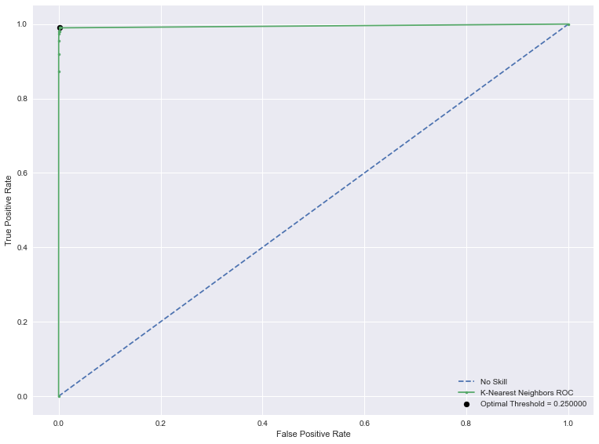

```python
roc_KNN = calculate_ROC(y_test, knn_probs_scaled, Type='K-Nearest Neighbors')
#roc_KNN = roc_curve(y_test, knn_probs_scaled)
#fpr, tpr, threshold = roc_curve(y_test, knn_probs_scaled)
#roc_auc = auc(fpr, tpr)
#roc_auc
```

```
Best Threshold=0.003224
```

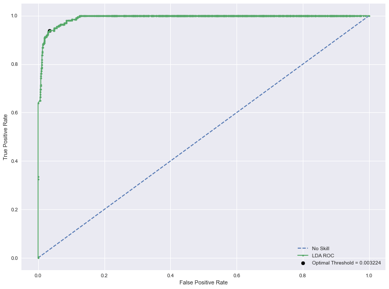

```python
roc_LDA = calculate_ROC(y_test, lda_probs, Type='LDA')
```

```
Best Threshold=0.029901
```

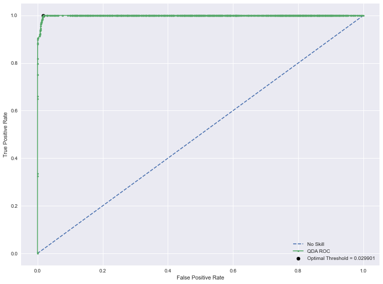

```python
roc_QDA = calculate_ROC(y_test, qda_probs, Type='QDA')
```

```
Best Threshold=0.025541
```

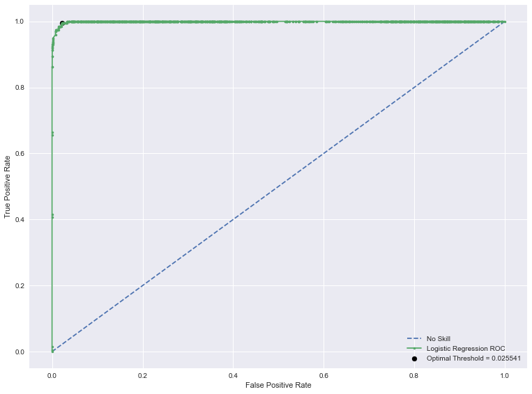

```python
roc_LogisticRegression = calculate_ROC(y_test, logreg_probs,Type='Logistic Regression')
```

```
Best Threshold=0.070379
```

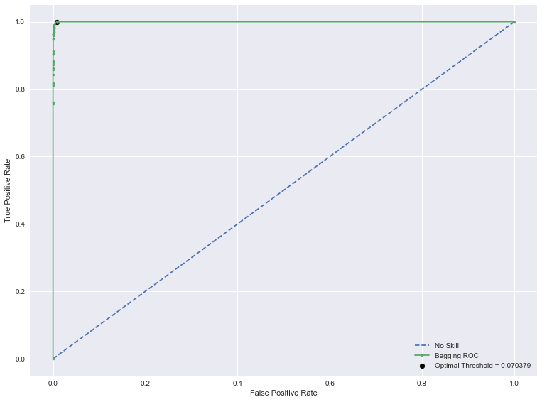

```python
roc_Bagging = calculate_ROC(y_test, bagging_probs,Type='Bagging')
```

```
Best Threshold=0.024627
```

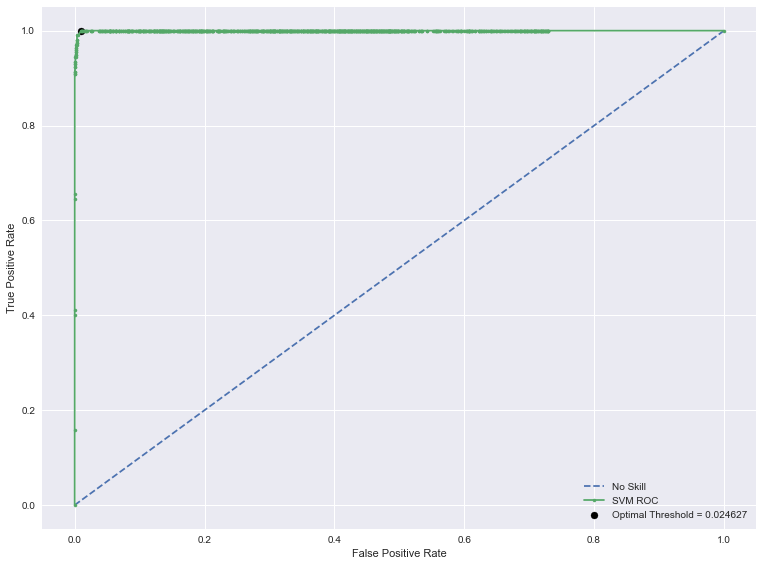

```python
roc_SVM = calculate_ROC(y_test, clf_svm_probs,Type='SVM')
```

#### Confusion Matrix

```python
def conf_m(y_test,pred):
    """The confusion_matrix() function can be used to produce a confusion matrix
    in order to determine how many observations were correctly or incorrectly
    classified."""
    # print(confusion_matrix(y_test, pred).T)
    #ValueError: multilabel-indicator is not supported
    ##https://stackoverflow.com/questions/46953967/multilabel-indicator-is-not-supported-for-confusion-matrix
    # print(confusion_matrix(y_test.argmax(), pred.argmax(axis)).T)

    #or, written this better way:
    conf_m = pd.DataFrame(confusion_matrix(y_test, pred))
    conf_m.columns.name = 'Predicted'
    conf_m.index.name = 'True'
    conf_m
    print(conf_m)

    # https://medium.com/ai-in-plain-english/understanding-confusion-matrix-and-applying-it-on-knn-classifier-on-iris-dataset-b57f85d05cd8

    """The classification_report() function gives us some summary
    statistics on the classifier's performance:"""

    # precision, recall, fbeta_score, support = precision_recall_fscore_support(y_test, knn_pred)
    # print(classification_report(y_test, logreg_pred, digits=3))

    # print("Sensitivity=Recall=Power: {}\nSpecificity=1-FPR: {}\nFPR: {}\nPrecision: {}".format())
    # print(Specificity)

    """
    the rows represent Actual Classes and the columns represent Class Predicted
    by the model. So the top left cell (483) represents the KNN model was successful
    at identifying 483 observations correctly labeled Blue Tarp, while 15 were
    labeled Rooftop, 5 were labeled Soil, 1 were labeled Various Non-Tarp, and 0
    were labeled Vegetation
    while those mis-classification numbers are low, I need to ensure that they
    stay even lower because the consequences for mis-classification are severe
    (people in haiti earthquake hiding under blue tarps will not be found)
    """
```

```python
#KNN
knn_confusion_matrix = conf_m(y_test,knn_pred)
knn_sensitivity = 0.9746192893 # 192/(192+5) TPR = Sensitivity = TP/(TP+FN) ... True Positive Rate (or Recall or Sensi
knn_specificity = 0.999510364 #1-0.0016332396942575292 Specificity = 1 - FPR = TN/(TN+FP) = 6124/(6124+ 3)
knn_fpr = 0.000489636 # 3/(6124+3) = FPR = 1 - Specificity = FP/(TN+FP) ... False Positive Rate defines how many incorrect positive results occur among all negative samples available during the test.
knn_precision = 0.9846153846 # 192/(192+3) Precision = TruePositives / (TruePositives + FalsePositives)
```

```
Predicted     0    1
True
0          6126    1
1             7  190
```

```python
#LDA
lda_confusion_matrix = conf_m(y_test,lda_pred_scaled)
lda_sensitivity = 0.7969543147 # 157/(157+40) TPR = Sensitivity = TP/(TP+FN) ... True Positive Rate (or Recall or Sensi
lda_specificity = 0.9890647952 #1-0.010844711569869995 = Specificity = 1 - FPR = TN/(TN+FP) = 6060/(6060+67)
lda_fpr = 0.01093520483 # 67/(6060+67) = FPR = 1 - Specificity = FP/(TN+FP) ... False Positive Rate defines how many incorrect positive results occur among all negative samples available during the test.
lda_precision = 0.7008928571 # 157/(157+67) Precision = TruePositives / (TruePositives + FalsePositives)
```

```
Predicted     0    1
True
0          6060   67
1            40  157
```

```python
#QDA
qda_confusion_matrix = conf_m(y_test,qda_pred)
qda_sensitivity = 0.8730964467 # 172/(172+25) TPR = Sensitivity = TP/(TP+FN) ... True Positive Rate (or Recall or Sensi
qda_specificity = 0.999510364 #1-0.00039197752662180704 = Specificity = 1 - FPR = TN/(TN+FP) = 6124/(6124+3)
qda_fpr = 0.0004896360372 # 6/(15301+6) = FPR = 1 - Specificity = FP/(TN+FP) ... False Positive Rate defines how many incorrect positive results occur among all negative samples available during the test.
qda_precision = 0.9828571429 # 172/(172+3) Precision = TruePositives / (TruePositives + FalsePositives)
```

```
Predicted     0    1
True
0          6124    3
1            25  172
```

```python
#Logistic Regression
logistic_regression_confusion_matrix = conf_m(y_test,logreg_pred)
logreg_sensitivity = 0.923857868 # 182/(182+15) TPR = Sensitivity = TP/(TP+FN) ... True Positive Rate (or Recall or Sensi
logreg_specificity = 0.9990207279 #1-0.0009146142287842164 Specificity = 1 - FPR = TN/(TN+FP) = 6121/(6121+6)
logreg_fpr = 0.0009792720744 # 14/(15293+14) = FPR = 1 - Specificity = FP/(TN+FP) ... False Positive Rate defines how many incorrect positive results occur among all negative samples available during the test.
logreg_precision = 0.9680851064 # 182/(182+6) Precision = TruePositives / (TruePositives + FalsePositives)
```

```
Predicted     0    1
True
0          6121    6
1            15  182
```

```python
#Bagging
#TN FP
#FN T
bagging_confusion_matrix = conf_m(y_test,bagging_pred)
bagging_sensitivity = 0.9471428571428572 # 663/(663+37) TPR = Sensitivity = TP/(TP+FN) ... True Positive Rate (or Recall or Sensi
bagging_specificity = 0.9985126425384234 #1-0.0009146142287842164 Specificity = 1 - FPR = TN/(TN+FP) = 20140/(20140+30)
bagging_fpr = 0.001487357461576599 # 30/(20140+30) = FPR = 1 - Specificity = FP/(TN+FP) ... False Positive Rate defines how many incorrect positive results occur among all negative samples available during the test.
bagging_precision = 0.9567099567099567 # 663/(663+30) Precision = TruePositives / (TruePositives + FalsePositives)
```

```
Predicted     0    1
True
0          6123    4
1             7  190
```

```python
#SVM
svm_confusion_matrix = conf_m(y_test, clf_svm_pred)
svm_sensitivity = 0.9471428571428572 # 663/(663+37) TPR = Sensitivity = TP/(TP+FN) ... True Positive Rate (or Recall or Sensi
svm_specificity = 0.9985126425384234 #1-0.0009146142287842164 Specificity = 1 - FPR = TN/(TN+FP) = 20140/(20140+30)
svm_fpr = 0.001487357461576599 # 30/(20140+30) = FPR = 1 - Specificity = FP/(TN+FP) ... False Positive Rate defines how many incorrect positive results occur among all negative samples available during the test.
svm_precision = 0.9567099567099567 # 663/(663+30) Precision = TruePositives / (TruePositives + FalsePositives)
```

```
Predicted     0    1
True
0          6117   10
1            10  187
```

### Table 2

[output not shown]

# Holdout Data

This next section uses the holdout data as the training set and the entire haiti pixels data as the test set.

```python
pixels.head(), pixels.info()
```

```
<class 'pandas.core.frame.DataFrame'>
RangeIndex: 63241 entries, 0 to 63240
Data columns (total 4 columns):
 #   Column  Non-Null Count  Dtype
---  ------  --------------  -----
 0   Class   63241 non-null  int64
 1   Red     63241 non-null  int64
 2   Green   63241 non-null  int64
 3   Blue    63241 non-null  int64
dtypes: int64(4)
memory usage: 1.9 MB
```

```
(   Class  Red  Green  Blue
 0      0   64     67    50
 1      0   64     67    50
 2      0   64     66    49
 3      0   75     82    53
 4      0   74     82    54,
 None)
```

```python
holdout.head(), holdout.info()
```

```
<class 'pandas.core.frame.DataFrame'>
RangeIndex: 2008623 entries, 0 to 2008622
Data columns (total 4 columns):
 #   Column  Dtype
---  ------  -----
 0   Red     int64
 1   Green   int64
 2   Blue    int64
 3   Class   int64
dtypes: int64(4)
memory usage: 61.3 MB
```

```
(   Red  Green  Blue  Class
 0  104     89    63      0
 1  101     80    60      0
 2  103     87    69      0
 3  107     93    72      0
 4  109     99    68      0,
 None)
```

Here I am going to call the load_data() function.

```python
# the pixels dataset will be used for testing
X_pixels, y_pixels = load_data(pixels)

#the holdout dataset will be used for training
X_holdout, y_holdout = load_data(holdout)
```

There is no use calling the kfold_train_test_split() I wrote because the holdout data is just going to be assigned to the training set and the pixels data is going to be assigned to the test set.

```python
# the pixels dataset will be used for testing
X_test_pixels, y_test_pixels = X_pixels, y_pixels

#the holdout dataset will be used for training
X_train_holdout, y_train_holdout = X_holdout, y_holdout
```

We still need to scale our data to help prevent data leakage and to reduce the run time on the SVM model.

```python
X_train_holdout_scaled, X_test_pixels_scaled = scale_X_data(X_train_holdout, X_test_pixels)
```

Now we can create the Random Forest model using the big training set. I am also going to calculate how long it takes to fit this model.

```python
import time # Just to compare fit times
start = time.time()

# using scaled X data for the bagging
bagging_pred_holdout, bagging_probs_holdout, rfc_holdout = bagging(X_train_holdout_scaled, X_test_pixels_scaled, y_train_holdout, y_test_pixels)

end = time.time()
print("Tune Fit Time:", end - start)
```

```
Tune Fit Time: 474.6934726238251
```

```python
bagging_pred_holdout
```

[output not shown]

For this first time around we are going to call the eval_perform_rf() function to evaluate the performance of the Random Forest model that was just built, using the test data from haiti pixels set. We are going to feed it unscaled data from the pixels set.

```python
# to compare fit times
start = time.time()

eval_perform_rf(rfc_holdout, X_pixels, y_pixels, y_test_pixels, bagging_pred_holdout)

end = time.time()
print("Tune Fit Time:", end - start)
```

```
CV=1: 1.0
CV=2: 0.9999482470298647
CV=3: 0.9975247524752475
CV=4: 1.0
CV=5: 1.0
CV=6: 1.0
CV=7: 0.9868721313490382
CV=8: 0.9940132325875515
CV=9: 0.9081534378527693
CV=10: 0.9993541574954349


=== Confusion Matrix ===
[[61214     5]
 [  611  1411]]


=== Classification Report ===
              precision    recall  f1-score   support

           0       0.99      1.00      0.99     61219
           1       1.00      0.70      0.82      2022

    accuracy                           0.99     63241
   macro avg       0.99      0.85      0.91     63241
weighted avg       0.99      0.99      0.99     63241



=== All AUC Scores ===
[1.         0.99994825 0.99752475 1.         1.         1.
 0.98687213 0.99401323 0.90815344 0.99935416]


=== Mean AUC Score ===
Mean AUC Score - Random Forest:  0.9885865958789907
Tune Fit Time: 6.196226119995117
```

For 611 observations we predicted that it was not a blue tarp where it really was a blue tarp and only predicted 5 blue tarps that really were not blue tarps. While these are really good scores, it's not ideal. I would actually like this to be the opposite: 5 False Negatives and 611 False Positives. The idea of people not being found outweighs thinking that something is a blue tarp when it really is not.

For our second time around, we will feed it scaled data from the holdout dataset.

```python
start = time.time()

eval_perform_rf(rfc_holdout, X_train_holdout_scaled, y_train_holdout, y_test_pixels, bagging_pred_holdout)

end = time.time()
print("Tune Fit Time:", end - start)
```

```
CV=1: 1.0
CV=2: 1.0
CV=3: 1.0
CV=4: 1.0
CV=5: 0.9999999920308404
CV=6: 0.9976446365271635
CV=7: 0.9900376606542723
CV=8: 0.9741268696549095
CV=9: 0.9944207304130871
CV=10: 0.9866697081245687


=== Confusion Matrix ===
[[61214     5]
 [  611  1411]]


=== Classification Report ===
              precision    recall  f1-score   support

           0       0.99      1.00      0.99     61219
           1       1.00      0.70      0.82      2022

    accuracy                           0.99     63241
   macro avg       0.99      0.85      0.91     63241
weighted avg       0.99      0.99      0.99     63241



=== All AUC Scores ===
[1.         1.         1.         1.         0.99999999 0.99764464
 0.99003766 0.97412687 0.99442073 0.98666971]


=== Mean AUC Score ===
Mean AUC Score - Random Forest:  0.9942899597404841
Tune Fit Time: 522.2331917285919
```

### Random Forest Hyperparameter Tuning

https://www.analyticsvidhya.com/blog/2020/03/beginners-guide-random-forest-hyperparameter-tuning/

This guide was instrumental in developing my understanding of which hyperparameters really matter when tuning a random forest model. Initially, my approach was to just throw a bunch of parameters into the param_grid and let the model identify the optimal parameters through the use of GridSearchCV. But this quickly proved to be unscalable. I tried upgrading this approach with RandomSearchCV but the big 2mil holdout dataset pummeled any hopes I had of using my original tuning function to fit the optimal random forest model. I needed to find a better solution to deal with large datasets.

In this guide from the analyticsvidhya.com article, I identified a few key parameters to focus on and learned how a much smaller range of options was necessary to pass to the gridsearch than I had initially thought. Here is a synopsis of my rationale for choosing the parameters that I did:

- **max_depth** determines the limit of the depth for each tree in the random forest. The performance of the model on training data increases continuously as max_depth increases because it gets closer and closer to a perfect fit of the data. Simultaneously, the fit on test data will decrease as max_depth increases since the model is overfit to the training data, and will thus perform poorly on the test data.
- **min_sample_split** determines the minimum number of observations for any node to split. By default this number is set to 2, which means that if any terminal node has more than two observations and is not a pure node, it can be split further into subnodes. As discussed above for max_depth, we want to avoid a random forest model comprised of trees with too many nodes, as that would indicate overfitting of the model. Leaving this min_sample_split number set to its default of 2 allows for this overfitting to occur, since 2 is so small and allows for trees to continue splitting until all the nodes are pure (1). "By increasing this number we can reduce the number of splits that happen in the decision tree and can thus prevent the model from overfitting" (or at least mitigate). However, it is important to not underfit this model (this is done by having the min_sample_split be too high, which would essentially lead to there being no significant splits observed, ultimately leading to a dip in both the training and test scores of model performance).
- **max_terminal_nodes / max_leaf_nodes** sets a condition on the splitting of the nodes in the tree, restricting the tree's growth. When the max_leaf_nodes is small, the random forest model will underfit.
- **min_samples_leaf** specifies the minimum number of samples that should be present in the leaf node after splitting a node. This is interesting to know but I'm not sure how helpful this will be in my model.
- **n_estimators** is super helpful for solving the exact problem I was having: as the number of trees used in the random forest model increases, so does the time complexity of the model. So, by limiting the n_estimators, we can control the time complexity from getting out of hand when working with large datasets.
- **max_samples** determines what fraction of the original dataset is given to any individual tree
- **max_features** determines the maximum number of features provided to each tree in the random forest model. The default value for this is set to the square root of the number of features present in the dataset. The ideal number of max_features generally tend to lie close to this value, so I will be leaving the max_features set to its default and will not be using it in the gridsearch.

```python
def rf_tune_hyperparameters(rfc_, X_train_rf_tune, y_train_rf_tune):
    #n_estimators determines the number of trees in the random forest
    n_estimators = [10, 50, 100]

    # max_depth determines the maximum depth of the tree
    max_depth = [4,8,12]

    #min_samples_split determines the number of observations needed to split a node
    min_samples_split = [5]

    # create grid of these parameters that will be passed into the searchCV function
    param_grid = {
     'n_estimators': n_estimators,
     'max_depth': max_depth,
     'min_samples_split': min_samples_split
     # 'max_features': max_features,
     }


    # GridSearchCV of the parameters
    rfc_gridsearch = GridSearchCV(
        rfc_,
        param_grid,
        # verbose=2,
        n_jobs=-1
        )

    # # Random search of parameters
    # rfc_random = RandomizedSearchCV(
    #     estimator = model,
    #     param_distributions = param_grid,
    #     n_iter = 100,
    #     cv = 3,
    #     verbose=2,
    #     random_state=313, n_jobs = -1)



    # Fit the model
    rfc_gridsearch.fit(X_train_rf_tune, y_train_rf_tune)


    # rfc_random.fit(X_train.to_numpy(), y_train.to_numpy())
    # this is a pretty data intensive model fit which is why i have set n_jobs to -1
    #in the RandomizedSearchCV(), which means that all of my processors are being
    #used in parallel to run this fit

    # print results
    # print(rfc_random.best_params_)



    #now store the optimal parameters and then return them for use in other functions
    optimal_n_estimators = rfc_gridsearch.best_params_['n_estimators']
    optimal_max_depth = rfc_gridsearch.best_params_['max_depth']
    optimal_min_samples_split = rfc_gridsearch.best_params_['min_samples_split']
    # optimal_max_features = rfc_gridsearch.best_params_['max_features']



    print("=== Optimal n_estimators ===")
    print(optimal_n_estimators)
    print('\n')

    print("=== Optimal optimal_max_depth ===")
    print(optimal_max_depth)
    print('\n')

    print("=== Optimal min_samples_split ===")
    print(optimal_min_samples_split)
    print('\n')

    # print("=== Optimal max_depth ===")
    # print(optimal_max_depth)
    # print('\n')

    # return rfc_random, optimal_n_estimators, optimal_max_features, optimal_max_depth
    return rfc_gridsearch, optimal_n_estimators, optimal_max_depth, optimal_min_samples_split
```

```python
start = time.time()

rfc_gridsearch, optimal_n_estimators, optimal_max_depth, optimal_min_samples_split = rf_tune_hyperparameters(rfc_holdout, X_train_holdout_scaled, y_train_holdout)

end = time.time()
print("Tune Fit Time:", end - start)
```

```
=== Optimal n_estimators ===
10


=== Optimal optimal_max_depth ===
12


=== Optimal min_samples_split ===
5


Tune Fit Time: 933.3132219314575
```

Now we can plug these optimal parameter values back into the model to see if they improve our model performance.

```python
def rf_optimal(X_train_rf_optimal, X_test_rf_optimal, y_train_rf_optimal, y_test_rf_optimal):
    rfc_optimal = RandomForestClassifier(
        n_estimators=optimal_n_estimators,
        max_depth=optimal_max_depth,
        min_samples_split=optimal_min_samples_split,
        random_state=313,
        n_jobs=-1)
    rfc_optimal.fit(X_train_rf_optimal, y_train_rf_optimal)
    rfc_optimal_predict = rfc_optimal.predict(X_test_rf_optimal)
    rfc_optimal_cv_score = cross_val_score(rfc_optimal, X_train_rf_optimal, y_train_rf_optimal, cv=10, scoring='roc_auc', n_jobs=-1)
    for i in range(len(rfc_optimal_cv_score)):
        print('CV={}: {}'.format(i+1,rfc_optimal_cv_score[i]))
    print('\n')

    print("=== Confusion Matrix ===")
    print(confusion_matrix(y_test_rf_optimal, rfc_optimal_predict))
    print('\n')
    # === Confusion Matrix ===
    # [[15289    18]
    #  [   25   479]]

    print("=== Classification Report ===")
    print(classification_report(y_test_rf_optimal, rfc_optimal_predict))
    print('\n')

    print("=== All AUC Scores ===")
    print(rfc_optimal_cv_score)
    print('\n')

    print("=== Mean AUC Score ===")
    print("Mean AUC Score - Random Forest: ", rfc_optimal_cv_score.mean())

    return rfc_optimal_cv_score
```

```python
start = time.time()

rf_optimal_cv_score = rf_optimal(X_train_holdout_scaled, X_test_pixels_scaled, y_train_holdout, y_test_pixels)

end = time.time()
print("Tune Fit Time:", end - start)
```

```
CV=1: 0.9999999256604689
CV=2: 1.0
CV=3: 0.9999999203505024
CV=4: 0.999999378405554
CV=5: 0.9999999973436134
CV=6: 0.9970048166131686
CV=7: 0.9913169949978118
CV=8: 0.9864831123087164
CV=9: 0.9951224951311811
CV=10: 0.9970546702323376


=== Confusion Matrix ===
[[61212     7]
 [  589  1433]]


=== Classification Report ===
              precision    recall  f1-score   support

           0       0.99      1.00      1.00     61219
           1       1.00      0.71      0.83      2022

    accuracy                           0.99     63241
   macro avg       0.99      0.85      0.91     63241
weighted avg       0.99      0.99      0.99     63241



=== All AUC Scores ===
[0.99999993 1.         0.99999992 0.99999938 1.         0.99700482
 0.99131699 0.98648311 0.9951225  0.99705467]


=== Mean AUC Score ===
Mean AUC Score - Random Forest:  0.9966981311043354
Tune Fit Time: 39.17140197753906
```